# Part I - Public Bicycle Scheme Analysis

## Introduction

> The bike sharing system also known as public bicycle scheme is a shared transport service that makes bicycle's accessible for short term use by individuals at low to no cost. The dataset contains information on the bicycle stations, bicycle, users information and trip duration around Sanfrancisco bay area.

## Preliminary Wrangling

```python
# import all packages and set plots to be embedded inline
import numpy as np
import pandas as pd
import matplotlib.pyplot as plt
import seaborn as sb

%matplotlib inline
```

```python
import matplotlib
print('matplotlib: {}'.format(matplotlib.__version__))
```

```
matplotlib: 3.6.0
```

```python
# read file into pandas dataframe.
bike_sharing = pd.read_csv('201902-fordgobike-tripdata.csv')
print(bike_sharing.shape)
bike_sharing.head(5)
```

```
(183412, 16)
```

|  | duration_sec | start_time | end_time | start_station_id | start_station_name | start_station_latitude | start_station_longitude | end_station_id | end_station_name | end_station_latitude | end_station_longitude | bike_id | user_type | member_birth_year | member_gender | bike_share_for_all_trip |
| --- | --- | --- | --- | --- | --- | --- | --- | --- | --- | --- | --- | --- | --- | --- | --- | --- |
| 0 | 52185 | 2019-02-28 17:32:10.1450 | 2019-03-01 08:01:55.9750 | 21.0 | Montgomery St BART Station (Market St at 2nd St) | 37.789625 | -122.400811 | 13.0 | Commercial St at Montgomery St | 37.794231 | -122.402923 | 4902 | Customer | 1984.0 | Male | No |
| 1 | 42521 | 2019-02-28 18:53:21.7890 | 2019-03-01 06:42:03.0560 | 23.0 | The Embarcadero at Steuart St | 37.791464 | -122.391034 | 81.0 | Berry St at 4th St | 37.775880 | -122.393170 | 2535 | Customer | NaN | NaN | No |
| 2 | 61854 | 2019-02-28 12:13:13.2180 | 2019-03-01 05:24:08.1460 | 86.0 | Market St at Dolores St | 37.769305 | -122.426826 | 3.0 | Powell St BART Station (Market St at 4th St) | 37.786375 | -122.404904 | 5905 | Customer | 1972.0 | Male | No |
| 3 | 36490 | 2019-02-28 17:54:26.0100 | 2019-03-01 04:02:36.8420 | 375.0 | Grove St at Masonic Ave | 37.774836 | -122.446546 | 70.0 | Central Ave at Fell St | 37.773311 | -122.444293 | 6638 | Subscriber | 1989.0 | Other | No |
| 4 | 1585 | 2019-02-28 23:54:18.5490 | 2019-03-01 00:20:44.0740 | 7.0 | Frank H Ogawa Plaza | 37.804562 | -122.271738 | 222.0 | 10th Ave at E 15th St | 37.792714 | -122.248780 | 4898 | Subscriber | 1974.0 | Male | Yes |

Date and time in the same column is a tidiness issue.

```python
bike_sharing.isnull().sum()
```

```
duration_sec                  0
start_time                    0
end_time                      0
start_station_id            197
start_station_name          197
start_station_latitude        0
start_station_longitude       0
end_station_id              197
end_station_name            197
end_station_latitude          0
end_station_longitude         0
bike_id                       0
user_type                     0
member_birth_year          8265
member_gender              8265
bike_share_for_all_trip       0
dtype: int64
```

```python
# percentage of missing value

missing_data_percent = (bike_sharing.isnull().sum()/bike_sharing.shape[0])*100
missing_data_percent = ['{:0.2f}%'.format(v) for v in missing_data_percent]
missing_data_percent
```

```
['0.00%',
 '0.00%',
 '0.00%',
 '0.11%',
 '0.11%',
 '0.00%',
 '0.00%',
 '0.11%',
 '0.11%',
 '0.00%',
 '0.00%',
 '0.00%',
 '0.00%',
 '4.51%',
 '4.51%',
 '0.00%']
```

maximum percentage of missing value is 4.51%

```python
# check for duplicate rows
bike_sharing.duplicated().sum()
```

```
0
```

```python
bike_sharing.dtypes
```

```
duration_sec                 int64
start_time                  object
end_time                    object
start_station_id           float64
start_station_name          object
start_station_latitude     float64
start_station_longitude    float64
end_station_id             float64
end_station_name            object
end_station_latitude       float64
end_station_longitude      float64
bike_id                      int64
user_type                   object
member_birth_year          float64
member_gender               object
bike_share_for_all_trip     object
dtype: object
```

Inappropriate datatypes noted

```python
bike_sharing.describe()
```

|  | duration_sec | start_station_id | start_station_latitude | start_station_longitude | end_station_id | end_station_latitude | end_station_longitude | bike_id | member_birth_year |
| --- | --- | --- | --- | --- | --- | --- | --- | --- | --- |
| count | 183412.000000 | 183215.000000 | 183412.000000 | 183412.000000 | 183215.000000 | 183412.000000 | 183412.000000 | 183412.000000 | 175147.000000 |
| mean | 726.078435 | 138.590427 | 37.771223 | -122.352664 | 136.249123 | 37.771427 | -122.352250 | 4472.906375 | 1984.806437 |
| std | 1794.389780 | 111.778864 | 0.099581 | 0.117097 | 111.515131 | 0.099490 | 0.116673 | 1664.383394 | 10.116689 |
| min | 61.000000 | 3.000000 | 37.317298 | -122.453704 | 3.000000 | 37.317298 | -122.453704 | 11.000000 | 1878.000000 |
| 25% | 325.000000 | 47.000000 | 37.770083 | -122.412408 | 44.000000 | 37.770407 | -122.411726 | 3777.000000 | 1980.000000 |
| 50% | 514.000000 | 104.000000 | 37.780760 | -122.398285 | 100.000000 | 37.781010 | -122.398279 | 4958.000000 | 1987.000000 |
| 75% | 796.000000 | 239.000000 | 37.797280 | -122.286533 | 235.000000 | 37.797320 | -122.288045 | 5502.000000 | 1992.000000 |
| max | 85444.000000 | 398.000000 | 37.880222 | -121.874119 | 398.000000 | 37.880222 | -121.874119 | 6645.000000 | 2001.000000 |

#### Data quality/ tidiness issues detected

> 1. Date and time in one column
2. Null Values(max = 4.51%)
3. Wrong datatypes for most columns

```python
# make copy of original dataset
bike_share = bike_sharing.copy()
```

```python
# split start_time and end_time column
time_col = ['start_time', 'end_time']

for i in time_col:
    name = i.split('_')[0] + '_' + 'date'
    name2 = i
    bike_share[[name, name2]] = bike_share[i].str.split(' ', expand = True)
bike_share.head(3)
```

|  | duration_sec | start_time | end_time | start_station_id | start_station_name | start_station_latitude | start_station_longitude | end_station_id | end_station_name | end_station_latitude | end_station_longitude | bike_id | user_type | member_birth_year | member_gender | bike_share_for_all_trip | start_date | end_date |
| --- | --- | --- | --- | --- | --- | --- | --- | --- | --- | --- | --- | --- | --- | --- | --- | --- | --- | --- |
| 0 | 52185 | 17:32:10.1450 | 08:01:55.9750 | 21.0 | Montgomery St BART Station (Market St at 2nd St) | 37.789625 | -122.400811 | 13.0 | Commercial St at Montgomery St | 37.794231 | -122.402923 | 4902 | Customer | 1984.0 | Male | No | 2019-02-28 | 2019-03-01 |
| 1 | 42521 | 18:53:21.7890 | 06:42:03.0560 | 23.0 | The Embarcadero at Steuart St | 37.791464 | -122.391034 | 81.0 | Berry St at 4th St | 37.775880 | -122.393170 | 2535 | Customer | NaN | NaN | No | 2019-02-28 | 2019-03-01 |
| 2 | 61854 | 12:13:13.2180 | 05:24:08.1460 | 86.0 | Market St at Dolores St | 37.769305 | -122.426826 | 3.0 | Powell St BART Station (Market St at 4th St) | 37.786375 | -122.404904 | 5905 | Customer | 1972.0 | Male | No | 2019-02-28 | 2019-03-01 |

```python
# since maximum percentage of null value is almost negligible (4.5%), I will drop all null rows.
bike_share.dropna(inplace = True)
bike_share.isnull().sum()
```

```
duration_sec               0
start_time                 0
end_time                   0
start_station_id           0
start_station_name         0
start_station_latitude     0
start_station_longitude    0
end_station_id             0
end_station_name           0
end_station_latitude       0
end_station_longitude      0
bike_id                    0
user_type                  0
member_birth_year          0
member_gender              0
bike_share_for_all_trip    0
start_date                 0
end_date                   0
dtype: int64
```

```python
col = ['start_time', 'end_time', 'start_date', 'end_date']
cols = ['start_station_id', 'end_station_id', 'bike_id']
for x in col:
    bike_share[x] = bike_share[x].apply(pd.to_datetime)

for y in cols:
    bike_share[y] = bike_share[y].astype(str)

bike_share['member_birth_year'] = bike_share['member_birth_year'].astype(int)

bike_share.dtypes
```

```
duration_sec                        int64
start_time                 datetime64[ns]
end_time                   datetime64[ns]
start_station_id                   object
start_station_name                 object
start_station_latitude            float64
start_station_longitude           float64
end_station_id                     object
end_station_name                   object
end_station_latitude              float64
end_station_longitude             float64
bike_id                            object
user_type                          object
member_birth_year                   int32
member_gender                      object
bike_share_for_all_trip            object
start_date                 datetime64[ns]
end_date                   datetime64[ns]
dtype: object
```

```python
# create more columns for increased insight
bike_share["member_age"] = 2019-bike_share['member_birth_year']
bike_share.head(3)
```

|  | duration_sec | start_time | end_time | start_station_id | start_station_name | start_station_latitude | start_station_longitude | end_station_id | end_station_name | end_station_latitude | end_station_longitude | bike_id | user_type | member_birth_year | member_gender | bike_share_for_all_trip | start_date | end_date | member_age |
| --- | --- | --- | --- | --- | --- | --- | --- | --- | --- | --- | --- | --- | --- | --- | --- | --- | --- | --- | --- |
| 0 | 52185 | 2022-11-07 17:32:10.145 | 2022-11-07 08:01:55.975 | 21.0 | Montgomery St BART Station (Market St at 2nd St) | 37.789625 | -122.400811 | 13.0 | Commercial St at Montgomery St | 37.794231 | -122.402923 | 4902 | Customer | 1984 | Male | No | 2019-02-28 | 2019-03-01 | 35 |
| 2 | 61854 | 2022-11-07 12:13:13.218 | 2022-11-07 05:24:08.146 | 86.0 | Market St at Dolores St | 37.769305 | -122.426826 | 3.0 | Powell St BART Station (Market St at 4th St) | 37.786375 | -122.404904 | 5905 | Customer | 1972 | Male | No | 2019-02-28 | 2019-03-01 | 47 |
| 3 | 36490 | 2022-11-07 17:54:26.010 | 2022-11-07 04:02:36.842 | 375.0 | Grove St at Masonic Ave | 37.774836 | -122.446546 | 70.0 | Central Ave at Fell St | 37.773311 | -122.444293 | 6638 | Subscriber | 1989 | Other | No | 2019-02-28 | 2019-03-01 | 30 |

```python
# create duration_minutes column and categorize.
bike_share['duration_min'] =  bike_share['duration_sec'] / 60
bike_share['duration_min'].describe()
```

```
count    174952.000000
mean         11.733379
std          27.370082
min           1.016667
25%           5.383333
50%           8.500000
75%          13.150000
max        1409.133333
Name: duration_min, dtype: float64
```

```python
#group trip to duration type
my_bins = [0,15,700,1410]
Labels = ['short', 'intermediate', 'long']
bike_share['duration_type'] = pd.cut(bike_share['duration_min'], bins=my_bins, labels = Labels, right = False)
bike_share['duration_type'].value_counts()
```

```
short           141939
intermediate     32929
long                84
Name: duration_type, dtype: int64
```

```python
bike_share['start_day']=bike_share['start_date'].dt.strftime('%a')
bike_share['start_hour']=bike_share['start_time'].dt.strftime('%H')
weekdays = ['Mon', 'Tue', 'Wed', 'Thu', 'Fri', 'Sat', 'Sun']
orderby = pd.api.types.CategoricalDtype(ordered = True, categories = weekdays)
bike_share['start_day'] = bike_share['start_day'].astype(orderby)
bike_share.head()
```

|  | duration_sec | start_time | end_time | start_station_id | start_station_name | start_station_latitude | start_station_longitude | end_station_id | end_station_name | end_station_latitude | ... | member_birth_year | member_gender | bike_share_for_all_trip | start_date | end_date | member_age | duration_min | duration_type | start_day | start_hour |
| --- | --- | --- | --- | --- | --- | --- | --- | --- | --- | --- | --- | --- | --- | --- | --- | --- | --- | --- | --- | --- | --- |
| 0 | 52185 | 2022-11-07 17:32:10.145 | 2022-11-07 08:01:55.975 | 21.0 | Montgomery St BART Station (Market St at 2nd St) | 37.789625 | -122.400811 | 13.0 | Commercial St at Montgomery St | 37.794231 | ... | 1984 | Male | No | 2019-02-28 | 2019-03-01 | 35 | 869.750000 | long | Thu | 17 |
| 2 | 61854 | 2022-11-07 12:13:13.218 | 2022-11-07 05:24:08.146 | 86.0 | Market St at Dolores St | 37.769305 | -122.426826 | 3.0 | Powell St BART Station (Market St at 4th St) | 37.786375 | ... | 1972 | Male | No | 2019-02-28 | 2019-03-01 | 47 | 1030.900000 | long | Thu | 12 |
| 3 | 36490 | 2022-11-07 17:54:26.010 | 2022-11-07 04:02:36.842 | 375.0 | Grove St at Masonic Ave | 37.774836 | -122.446546 | 70.0 | Central Ave at Fell St | 37.773311 | ... | 1989 | Other | No | 2019-02-28 | 2019-03-01 | 30 | 608.166667 | intermediate | Thu | 17 |
| 4 | 1585 | 2022-11-07 23:54:18.549 | 2022-11-07 00:20:44.074 | 7.0 | Frank H Ogawa Plaza | 37.804562 | -122.271738 | 222.0 | 10th Ave at E 15th St | 37.792714 | ... | 1974 | Male | Yes | 2019-02-28 | 2019-03-01 | 45 | 26.416667 | intermediate | Thu | 23 |
| 5 | 1793 | 2022-11-07 23:49:58.632 | 2022-11-07 00:19:51.760 | 93.0 | 4th St at Mission Bay Blvd S | 37.770407 | -122.391198 | 323.0 | Broadway at Kearny | 37.798014 | ... | 1959 | Male | No | 2019-02-28 | 2019-03-01 | 60 | 29.883333 | intermediate | Thu | 23 |

5 rows × 23 columns

```python
hours = ['00','01','02','03','04','05','06','07','08','09','10','11','12','13','14','15','16','17','18','19','20','21','22','23','24']
orderby = pd.api.types.CategoricalDtype(ordered = True, categories = hours)
bike_share['start_hour'] = bike_share['start_hour'].astype(orderby)
```

```python
#dataframe current info
bike_share.info()
```

```
<class 'pandas.core.frame.DataFrame'>
Int64Index: 174952 entries, 0 to 183411
Data columns (total 23 columns):
 #   Column                   Non-Null Count   Dtype
---  ------                   --------------   -----
 0   duration_sec             174952 non-null  int64
 1   start_time               174952 non-null  datetime64[ns]
 2   end_time                 174952 non-null  datetime64[ns]
 3   start_station_id         174952 non-null  object
 4   start_station_name       174952 non-null  object
 5   start_station_latitude   174952 non-null  float64
 6   start_station_longitude  174952 non-null  float64
 7   end_station_id           174952 non-null  object
 8   end_station_name         174952 non-null  object
 9   end_station_latitude     174952 non-null  float64
 10  end_station_longitude    174952 non-null  float64
 11  bike_id                  174952 non-null  object
 12  user_type                174952 non-null  object
 13  member_birth_year        174952 non-null  int32
 14  member_gender            174952 non-null  object
 15  bike_share_for_all_trip  174952 non-null  object
 16  start_date               174952 non-null  datetime64[ns]
 17  end_date                 174952 non-null  datetime64[ns]
 18  member_age               174952 non-null  int32
 19  duration_min             174952 non-null  float64
 20  duration_type            174952 non-null  category
 21  start_day                174952 non-null  category
 22  start_hour               174952 non-null  category
dtypes: category(3), datetime64[ns](4), float64(5), int32(2), int64(1), object(8)
memory usage: 27.2+ MB
```

### What is the structure of your dataset?

> The dataset contains 183412 rows and 16columns. it contains information on users including the user gender, membership type, year of birth and use for all trip. It also contains information on the bike stations, both start and end stations which includes their name, latitude and longitude. station_id and bike_id are specific for each station and bike.

> There are both quantitative and qualitative variable types:

```
latitude, longitude variables(continious numeric datatype);
ids,names,birth year, gender(qualitative datatype);
start and end time, duration sec(interval numeric datatype)
```

### What is/are the main feature(s) of interest in your dataset?

> 1. duration_min

### What features in the dataset do you think will help support your investigation into your feature(s) of interest?

> 1. member_age
2. duration_type
3. gender
4. start_day
5. start_hour
6. user_type

## Univariate Exploration

Explore the features of interest individually

```python
# create function to plot univariant plots

def univariant_plot(plottype, columnname):
    plt.figure(figsize=(5,3))
    name = (columnname)
    plt.title(f'trip distribution over {name}')
    if 'pie' in str(plottype):
        column = bike_share[columnname].value_counts()
        label = column.index
        my_color = sb.color_palette('pastel')
        def func(pct):
            return '{:1.1f}%'.format(pct)
        plottype(data=bike_share, x=column, colors=my_color, labels=label, counterclock=False, startangle=90, autopct=lambda pct: func(pct), normalize=True, explode = (0,0.05,0.05));
        plt.axis('square')
    elif 'hist' in str(plottype):
        my_bin=input('binsize')
        colour = sb.color_palette()[-1]
        plottype(data = bike_share, x = columnname, color = colour, bins = int(my_bin) )
        plt.xlabel(name)
        plt.ylabel('Count')
    else:
        colour = sb.color_palette()[-1]
        a = bike_share[columnname].value_counts(normalize=True)
        b = a.index
        c = a.values
        plottype(data = bike_share, x = b, y = c, color = colour);
        plt.xticks(rotation=90)
        plt.xlabel(name)
        plt.ylabel('Proportion')
```

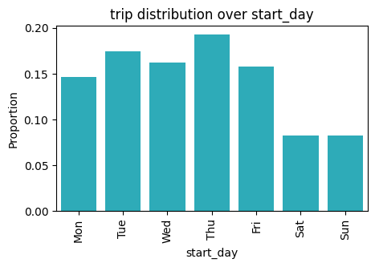

```python
# distribution of trip over start_day

univariant_plot(sb.barplot, 'start_day')
```

**Conclusion:** most trip were taken during the week/Work days with thursday as the highest.

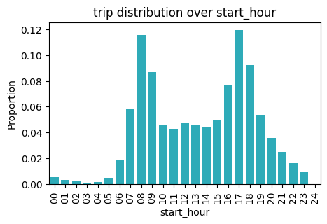

```python
# trip distribution over hour
univariant_plot(sb.barplot, 'start_hour')
```

**Conclusion:** Most trips were made between 7-9am and 4-6pm. This corresponds to usual start time for work and close hour

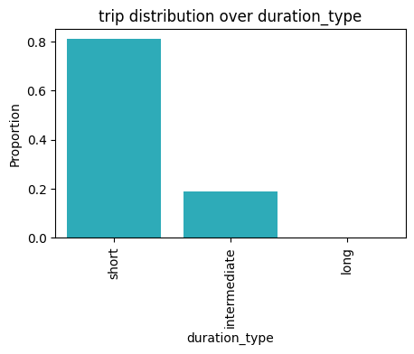

```python
#trip distribution over duration_type
univariant_plot(sb.barplot, 'duration_type')
```

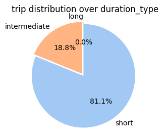

```python
univariant_plot(plt.pie, 'duration_type')
```

**Conclusion:** 81.1% of trip made were short trip i.e between 1 - 15minutes.

```
binsize1000
```

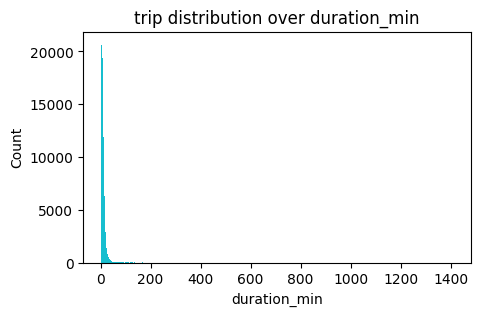

```python
#trip distribution by time in minute
univariant_plot(plt.hist, 'duration_min')
```

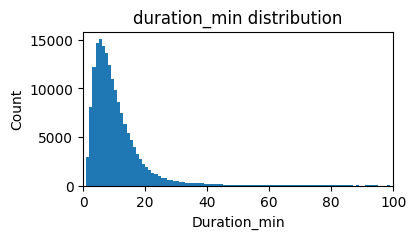

```python
# limit x axis to 0-100
my_bins= np.arange(0, bike_share['duration_min'].max() + 1, 1)
plt.figure(figsize=(4,2))
plt.hist(data=bike_share, x='duration_min', bins=my_bins);
plt.xlim(0,100);
plt.title('duration_min distribution');
plt.xlabel('Duration_min');
plt.ylabel('Count');
```

**Conclusion:** From the pie chart above, long trip was approximately 0.0% of our data and intermediate was 18.8% however from the histogram, we will notice that this percentage came between 16 to 60 mins. The rest of the time will be treated as outliers and removed

```python
# remove duration_min outlier
bike_share = bike_share.query('duration_min <= 60')
bike_share.shape
```

```
(173566, 23)
```

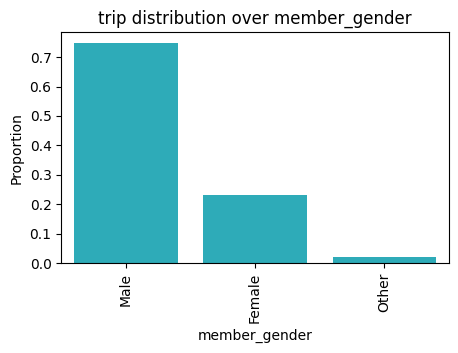

```python
#trip distribution by gender
univariant_plot(sb.barplot, 'member_gender')
```

**Conclusion:** approximately 75% of bike users are male, 25% female and less than 5% other genders

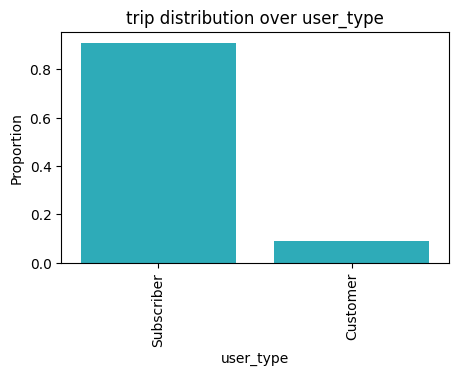

```python
#trip distribution by user_type
univariant_plot(sb.barplot, 'user_type')
```

**Conclusion:** approximately 90% of bike users are subscribers

```
binsize15
```

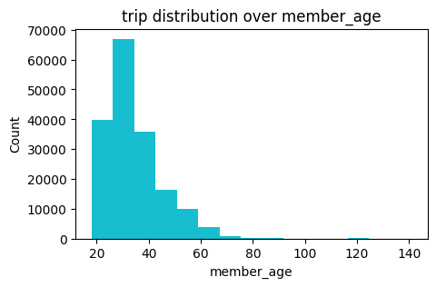

```python
#trip distribution by age
univariant_plot(plt.hist, 'member_age')
```

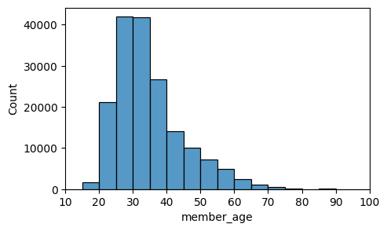

```python
plt.figure(figsize=(5,3))
my_bins= np.arange(0, bike_share['member_age'].max() + 5, 5)
sb.histplot(data=bike_share, x='member_age', bins=my_bins);
plt.xlim(10,100);
```

**Conclusion:** From age distribution, the system had more users within age 25-35. This use declines continiously to age 90. Age above 90 will be considered outlier and cleared from the data

```python
# remove age outlier
bike_share = bike_share.query('member_age <= 90')
bike_share.shape
```

```
(173489, 23)
```

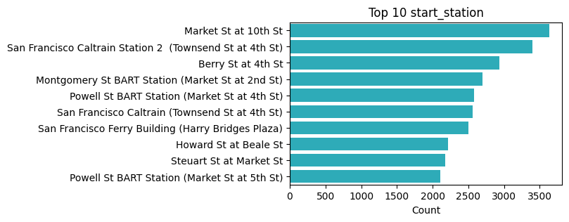

```python
form = bike_share['start_station_name'].value_counts().head(10)
name = form.index
value = form.values
plt.figure(figsize=(5,3))
my_color = sb.color_palette()[-1];
sb.barplot(data=bike_share, y= name, x= value, color = my_color);
plt.title('Top 10 start_station')
plt.xlabel('Count')
```

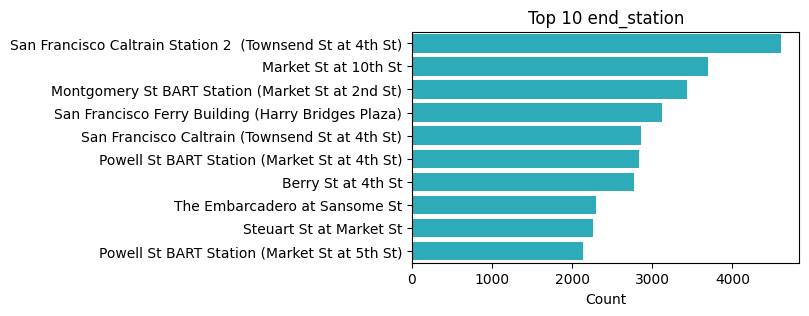

```python
form1 = bike_share['end_station_name'].value_counts().head(10)
name1 = form1.index
value1 = form1.values
plt.figure(figsize=(5,3))
my_color = sb.color_palette()[-1];
sb.barplot(data=bike_share, y= name1, x= value1, color = my_color);
plt.title('Top 10 end_station');
plt.xlabel('Count');
```

```python
#form in form1
name = list(name)
name1 = list(name1)
for i in name:
    if i in name1:
        pass
    else:
        print('differnce spotted')
print('Done')
```

```
differnce spotted
Done
```

Just one difference was spotted between the start and end stations.

### Discuss the distribution(s) of your variable(s) of interest. Were there any unusual points? Did you need to perform any transformations?

The age column and duration_min column had outliers. The outliers were removed from the dataset.

The start_time and end_time column was splited to seperate date and time. More number of trip was taken at certain hours of the day and days of the week.

9 out of the top ten(10) start and end station are the same. This points that major trips were made along these stations.

## Bivariate Exploration

```python
def bivariant_plot(plottype, column1, column2):
    plt.figure(figsize=(6,4))
    name = column1
    name2 = column2
    plt.title(f'{name} against {name2}')

    if 'reg' in str(plottype):
        bike_share_samp = bike_share.sample(n=10000, replace=False)
        my_color = sb.color_palette()[4]
        trans = input('transparency scale')
        jitters = input('jitters')
        plottype(data = bike_share_samp, x=column1, y=column2, scatter_kws={'alpha':float(trans)}, x_jitter= float(jitters))
        plt.axis('square')
    elif 'count' in str(plottype):
        plottype(data = bike_share, x = column1, hue = column2)
    else:
        colour = sb.color_palette()[-1]
        plottype(data = bike_share, x = column1, y = column2, color = colour);
        plt.xticks(rotation=30)
```

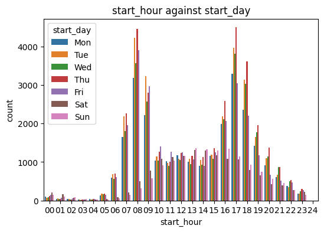

```python
# comparison between start_hour and start_day
bivariant_plot(sb.countplot, 'start_hour', 'start_day')
```

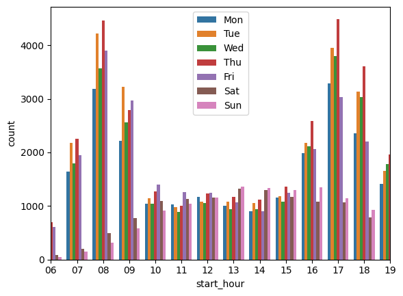

```python
sb.countplot(data = bike_share, x='start_hour', hue='start_day');
plt.legend();
plt.xlim(6,19);
```

**Conclusion:** Most ride was by 8am and 5pm. A more closer look showed that Thursday and Tuesday has the highest engagement across 7am - 9am and 4pm - 6pm. Weekend trips are more usually by 12pm - 4pm.

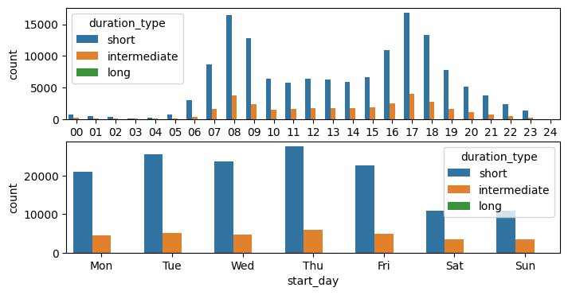

```python
fig, ax = plt.subplots(nrows=2, figsize = [8,4])

sb.countplot(data = bike_share, x= 'start_hour', hue = 'duration_type', ax = ax[0]);
sb.countplot(data = bike_share, x= 'start_day', hue = 'duration_type', ax = ax[1]);
```

**Conclusion:** Number of short trips taken at each hour and on each day is higher than number of intermediate trips.

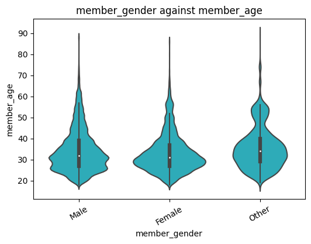

```python
bivariant_plot(sb.violinplot, 'member_gender', 'member_age')
```

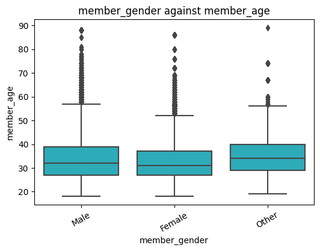

```python
# distribution of gender against age
bivariant_plot(sb.boxplot, 'member_gender', 'member_age')
# ask caleb
```

**Conclusion:** Age range is distributed faily across all gender with Males with highest age range and outliers.

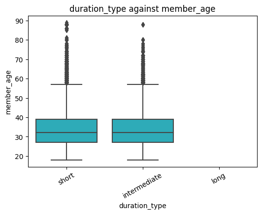

```python
bivariant_plot(sb.boxplot, 'duration_type', 'member_age')
```

**Conclusion:** The boxplot shows that both short and intermediate trips has approximately equal median and interquartile range therefore age had no much effect on the duration of the trip taken.

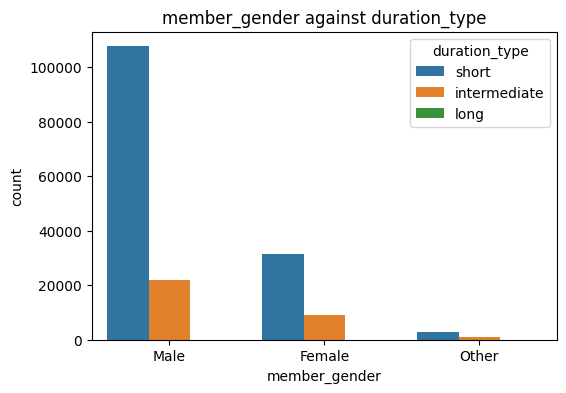

```python
bivariant_plot(sb.countplot, 'member_gender', 'duration_type')
```

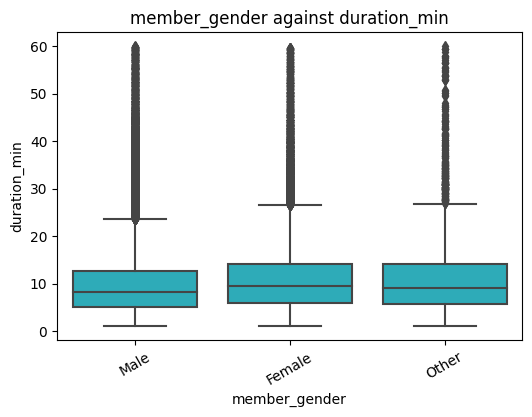

```python
bivariant_plot(sb.boxplot, 'member_gender', 'duration_min')
```

**Conclusion:** Short trips has highest distribution accross all genders. From the box plot however, it can be deduced that men generally took shorter trips compared to females and other gender.

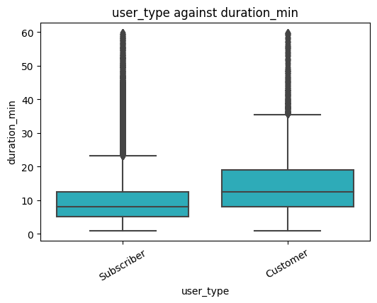

```python
bivariant_plot(sb.boxplot, 'user_type', 'duration_min')
```

**Conclusion:** The median and interquartile range of subscribers ae smaller than customers. Users who subscribe to the service, take shorter trips compared to regular customers.

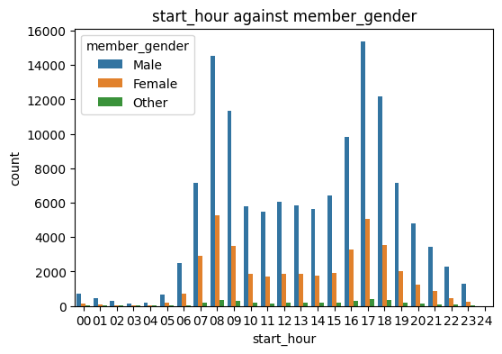

```python
bivariant_plot(sb.countplot, 'start_hour', 'member_gender')
```

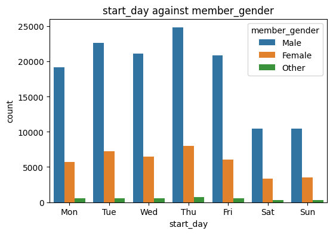

```python
bivariant_plot(sb.countplot, 'start_day', 'member_gender')
```

**Conclusion:** Pattern of use is same across all gender. Workdays having highest engagement between 7-9am and 4-6pm. It is also worthy of note that number of male users dropped significantly during the weekends

```
transparency scale0.05
jitters0.3
```

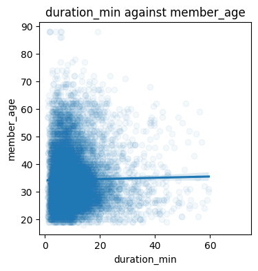

```python
bivariant_plot(sb.regplot, 'duration_min', 'member_age')
```

## Multivariate Exploration

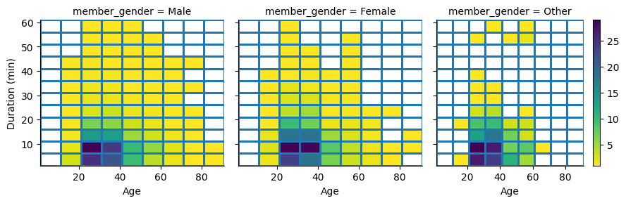

```python
data_sample = bike_share.sample(n=10000, replace= False)
g=sb.FacetGrid(data = data_sample, col = 'member_gender')
ybin = np.arange(1,bike_share.duration_min.max()+5, 5)
xbin = np.arange(1,bike_share.member_age.max()+10, 10)
g.map(plt.hist2d, 'member_age', 'duration_min', cmap = 'viridis_r', cmin = 0.5, bins = [xbin,ybin]);
g.set_xlabels('Age');
g.set_ylabels('Duration (min)');
plt.colorbar();
```

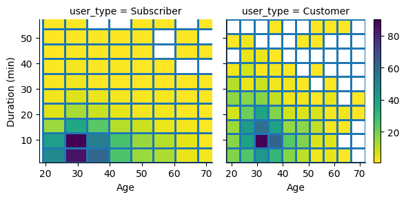

```python
data_sample = bike_share.sample(n=10000, replace= False)
g=sb.FacetGrid(data = data_sample, col = 'user_type')
g.map(plt.hist2d, 'member_age', 'duration_min',bins = [10,10], cmap = 'viridis_r', cmin = 0.5);
g.set_xlabels('Age');
g.set_ylabels('Duration (min)');
plt.colorbar();
```

```python
bike_share.to_csv('slide_file.csv', index=False)
```